# Лабораторная работа 1: «Метод обратного распространения ошибки»

## Выполнил студент

ФИО: **Рштуни Владислав Дмитриевич**

Группа: **3825М1сФИ1**

## Цель работы

**Цель** - изучить метод обратного распространения ошибки для обучения глубоких нейронных сетей на примере двухслойной полносвязной нейронной сети (один скрытый слой).

## Задачи работы

Выполнение лабораторной работы предполагает решение следующих задач:

1. Изучить общую схему работы метода обратного распространения ошибки с использованием стохастического градиентного спуска.
2. Вывести формулы для вычисления градиентов функции ошибки по параметрам нейронной сети и формулы коррекции весов.
3. Загрузить набор данных [MNIST](https://www.kaggle.com/datasets/hojjatk/mnist-dataset), выполнить предобработку изображений и меток, если это необходимо.
4. Реализовать и протестировать метод обратного распространения ошибки для задачи классификации рукописных цифр из набора данных MNIST.

## Конфигурация нейронной сети

1. **Входной слой** содержит `w x h` нейронов, что соответствует разрешению одноканального изображения. Для набора MNIST это составляет `28 x 28`.
2. **Выходной слой** содержит `k` нейронов, что соответствует количеству классов изображений. Для задачи классификации рукописных цифр MNIST - 10 классов.
3. **Скрытый слой** содержит `s` нейронов (параметр).
4. **Метод обучения** - стохастический градиентный спуск по пачкам данных. Параметры:
   - Скорость обучения (learning rate)
   - Размер пачки данных (batch size)
   - Количество эпох
5. **Функции активации**:
   - На скрытом слое - функция ReLU.
   - На выходном слое - функция softmax.
   - Входной слой не содержит функции активации.
6. **Функция ошибки** - кросс-энтропия. **softmax вместе с кросс-энтропией упрощает вывод формул**.
7. **Контрольные параметры для демонстрации работы нейронной сети**:
   - Размер пачки данных: от 8 до 64 изображений (в зависимости от доступного объема памяти).
   - Скорость обучения: 0.1.
   - Количество скрытых нейронов `s`: 300.
   - Количество эпох: 20.

## Требования к результатам выполнения работы

1. **Структура и содержимое Jupyter Notebook**:
   - Вывести размерности данных: количество примеров в каждой выборке, форму одного изображения и меток.
   - Показать несколько изображений с метками классов, чтобы подтвердить корректность загрузки.
   - После каждой эпохи обучения модели выводится ошибка классификации на тренировочном наборе данных и время выполнения эпохи.
   - После обучения выводится ошибка классификации на тестовом наборе данных.
2. **Точность классификации**:
   - Для контрольных параметров достигнута точность классификации на тестовых данных, сравнимая с той, что дают стандартные фреймворки глубокого обучения (например, Keras или PyTorch).
   - Подсказка: Точность будет ~95% с **неправильной** инициализацией весов. В лабораторной работе ожидается результат **лучше**.
3. **Время выполнения**:
   - Запуск необходимо выполнить в процессе очной сдачи.
   - Время обучения на контрольных параметрах не должно превышать время, выделенное на сдачу работы одним студентом (~7–15 минут).
4. **Реализация**:
   - Реализация не должна содержать использование фреймворков глубокого обучения (TensorFlow, Keras, PyTorch и т.д.).
   - Допускается использование NumPy, Matplotlib и других классических библиотек.

## Оценивание

- **Зачтено / Не зачтено**

## Используемые библиотеки

Встроенные модули:

1. [os](https://docs.python.org/3/library/os.html)
2. [time](https://docs.python.org/3/library/time.html)

Классические библиотеки:

1. [numpy](https://numpy.org/)
2. [matplotlib](https://matplotlib.org/)

Сторонние библиотеки:

1. kagglehub
2. [ubyte](https://pypi.org/project/ubyte/)

Установка:

```
pip install numpy matplotlib kagglehub ubyte
```

# Тестовый стенд

Hardware Information:

- **Процессор:** AMD Ryzen 5 5600H (6C/12T)
- **Оперативная память:** 2 × 8 GB DDR4

Software Information:

- **ОС:** Arch Linux x86_64
- **Ядро:** Linux 7.2.8-arch1-2
- **Python** 3.14.7

```python
import os
import time

import numpy as np
from matplotlib import pyplot as plt

np.random.seed(42)

NAME_DATASET = "hojjatk/mnist-dataset"
NUM_CLASSES = 10
INPUT_SIZE = 28 * 28

HIDDEN = 300
EPOCHS = 20
BATCH_SIZE = 64
LR = 0.1
```

## 2. Загрузка и предобработка данных

Датасет MNIST скачивается через `kagglehub` и декодируется библиотекой `ubyte`.  
Изображения приводятся к диапазону $[0, 1]$ и разворачиваются в вектор длины 784, метки кодируются one-hot.

```python
if not os.path.isdir('./datasets/' + NAME_DATASET):
    import kagglehub
    os.environ["KAGGLEHUB_CACHE"] = "./"
    path = kagglehub.dataset_download(NAME_DATASET)
    time.sleep(2)

import ubyte

path = './datasets/' + NAME_DATASET

train_images = ubyte.decode_idx3_ubyte(path + '/versions/1/train-images.idx3-ubyte')
train_labels = ubyte.decode_idx1_ubyte(path + '/versions/1/train-labels.idx1-ubyte')
test_images  = ubyte.decode_idx3_ubyte(path + '/versions/1/t10k-images.idx3-ubyte')
test_labels  = ubyte.decode_idx1_ubyte(path + '/versions/1/t10k-labels.idx1-ubyte')
```

[output not shown]

[output cut: 9 more lines]

[output not shown]

```python
print('Размернось изображений для обучения:', train_images.shape)
print('Количество меток для обучения:', train_labels.shape, '\n')

print('Размернось изображений для тестирования:', test_images.shape)
print('Количество меток для тестирования:', test_labels.shape, '\n')

print('Размеры изображения:', train_images.shape[1:], '| Количество классов: ', NUM_CLASSES)
```

```
Размернось изображений для обучения: (60000, 28, 28)
Количество меток для обучения: (60000,)

Размернось изображений для тестирования: (10000, 28, 28)
Количество меток для тестирования: (10000,)

Размеры изображения: (28, 28) | Количество классов:  10
```

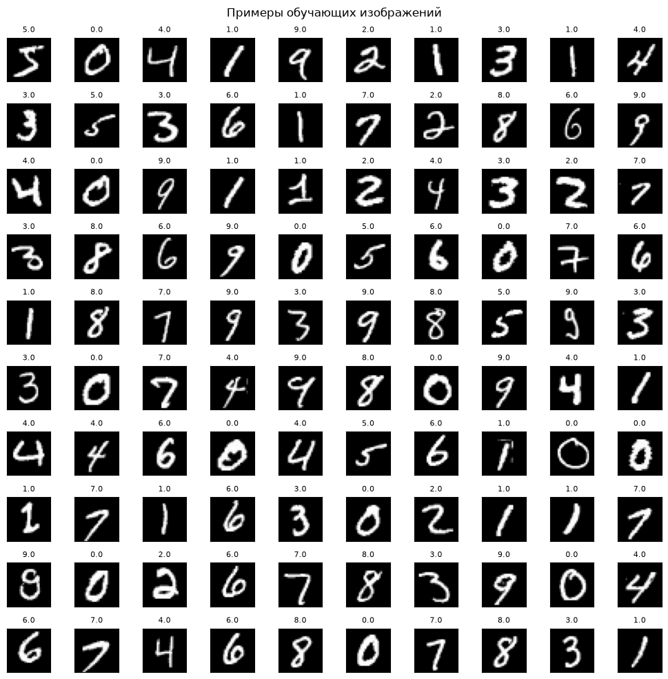

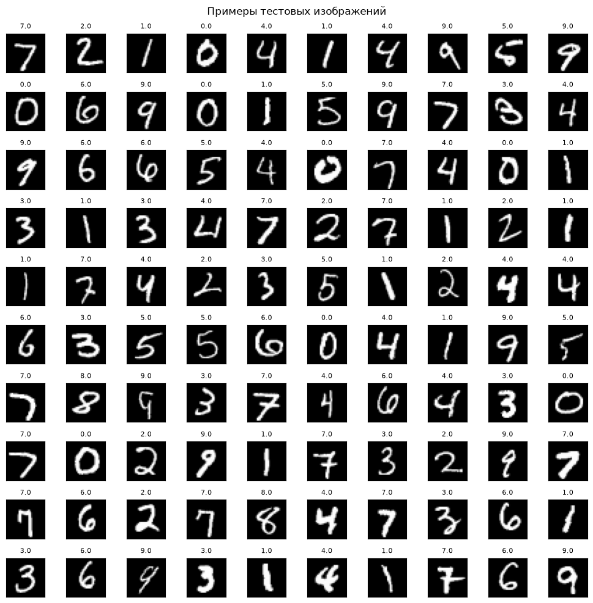

```python
def show_images(images, labels, title, num=100):
    num_x, num_y = 10, 10
    fig, axes = plt.subplots(num_y, num_x, figsize=(10, 10))
    fig.suptitle(title)
    plt.setp(axes, xticks=[], yticks=[])

    for i, ax in enumerate(axes.flat):
        if i >= min(num, len(images)):
            break
        img = np.asarray(images[i]).squeeze()
        ax.imshow(img, cmap='gray', vmin=0, vmax=255)
        ax.set_title(str(labels[i]), fontsize=8)

    plt.tight_layout()
    plt.show()

show_images(train_images, train_labels, 'Примеры обучающих изображений', num=100)
show_images(test_images, test_labels, 'Примеры тестовых изображений', num=100)
```

```python
X_train = (train_images.astype(np.float32) / 255.0).reshape(len(train_images), -1)
y_train = train_labels.astype(np.int64)

X_test  = (test_images.astype(np.float32)  / 255.0).reshape(len(test_images),  -1)
y_test  = test_labels.astype(np.int64)

def one_hot(y, k=10):
    out = np.zeros((len(y), k), dtype=np.float32)
    out[np.arange(len(y)), y] = 1.0
    return out

T_train = one_hot(y_train)
T_test  = one_hot(y_test)

print(f'X_train: {X_train.shape} | X_test: {X_test.shape}')
print(f'y_train: {y_train.shape} | y_test: {y_test.shape}')
print(f'Pixel range: {X_train.min()} - {X_train.max()}')
print(f'T_train: {T_train.shape} | T_test: {T_test.shape}')
```

```
X_train: (60000, 784) | X_test: (10000, 784)
y_train: (60000,) | y_test: (10000,)
Pixel range: 0.0 - 1.0
T_train: (60000, 10) | T_test: (10000, 10)
```

## 3. Реализация слоёв и сети

Реализуем три компонента:

- `Dense` — полносвязный слой с поддержкой батчей;
- `ReLU` — функция активации скрытого слоя;
- `SoftmaxCrossEntropy` — совместный слой softmax + кросс-энтропия с аналитическим градиентом $\partial L / \partial z = (p - t)/B$.

```python
class Dense:
    def __init__(self, in_size, out_size):
        self.W = (np.random.randn(out_size, in_size) * np.sqrt(2.0 / in_size)).astype(np.float32)
        self.b = np.zeros(out_size, dtype=np.float32)
        self.x = None
        self.dW = None
        self.db = None

    def forward(self, x):
        self.x = x
        if x.ndim == 1:
            return self.W @ x + self.b

        return x @ self.W.T + self.b

    def backward(self, dout):
        if self.x.ndim == 1:
            self.dW = np.outer(dout, self.x)
            self.db = dout
            return self.W.T @ dout

        self.dW = dout.T @ self.x
        self.db = dout.sum(axis=0)
        return dout @ self.W


class ReLU:
    def __init__(self):
        self.mask = None

    def forward(self, x):
        self.mask = (x > 0)
        return x * self.mask

    def backward(self, dout):
        return dout * self.mask


class SoftmaxCrossEntropy:
    def __init__(self):
        self.p = None
        self.t = None

    def forward(self, z, t):
        z_shift = z - z.max(axis=1, keepdims=True)
        exp = np.exp(z_shift)
        self.p = exp / exp.sum(axis=1, keepdims=True)
        self.t = t
        return -np.mean(np.sum(t * np.log(self.p + 1e-12), axis=1))

    def backward(self):
        return (self.p - self.t) / self.p.shape[0]
```

```python
class TwoLayerNet:
    def __init__(self, in_size=784, hidden=300, out_size=10):
        self.fc1  = Dense(in_size, hidden)
        self.relu = ReLU()
        self.fc2  = Dense(hidden, out_size)
        self.loss = SoftmaxCrossEntropy()

    def forward(self, x, t=None):
        h = self.relu.forward(self.fc1.forward(x))
        z = self.fc2.forward(h)
        if t is None:
            return z

        return self.loss.forward(z, t)

    def backward(self):
        dz = self.loss.backward()
        dh = self.fc2.backward(dz)
        d1 = self.relu.backward(dh)
        self.fc1.backward(d1)

    def step(self, lr):
        self.fc1.W -= lr * self.fc1.dW
        self.fc1.b -= lr * self.fc1.db
        self.fc2.W -= lr * self.fc2.dW
        self.fc2.b -= lr * self.fc2.db
```

```python
def predict(net, X):
    return net.forward(X).argmax(axis=1)

def accuracy(net, X, y):
    return (predict(net, X) == y).mean()

def train(net, X_train, T_train, y_train, X_test, y_test,
          epochs=20, batch_size=64, lr=0.1):
    N = len(X_train)
    history = []

    for ep in range(epochs):
        t0 = time.time()
        perm = np.random.permutation(N)
        total_loss, nb = 0.0, 0

        for i in range(0, N, batch_size):
            idx = perm[i:i + batch_size]
            xb, tb = X_train[idx], T_train[idx]

            loss = net.forward(xb, tb)
            net.backward()
            net.step(lr)

            total_loss += loss
            nb += 1

        train_err = 1.0 - accuracy(net, X_train, y_train)
        test_acc  = accuracy(net, X_test, y_test)
        dt = time.time() - t0

        history.append((ep + 1, total_loss / nb, train_err, test_acc, dt))

        print(f"Epoch {ep+1:2d}/{epochs} | loss {total_loss/nb:.4f} | "
              f"train err {train_err*100:5.2f}% | test acc {test_acc*100:5.2f}% | {dt:5.1f}s")
    return history
```

## 4. Обучение сети

Параметры из задания:

- batch size = 64
- learning rate = 0.1
- hidden = 300
- epochs = 20

```python
net = TwoLayerNet(in_size=INPUT_SIZE, hidden=HIDDEN, out_size=NUM_CLASSES)

t_start = time.time()
history = train(net, X_train, T_train, y_train, X_test, y_test,
                epochs=EPOCHS, batch_size=BATCH_SIZE, lr=LR)

print(f"\nОбщее время обучения: {time.time() - t_start:.1f}s")
```

[output not shown]

```
Train Accuracy: 99.77%
Train Error:    0.23%
Test  Accuracy: 98.19%
Test  Error:    1.81%
```

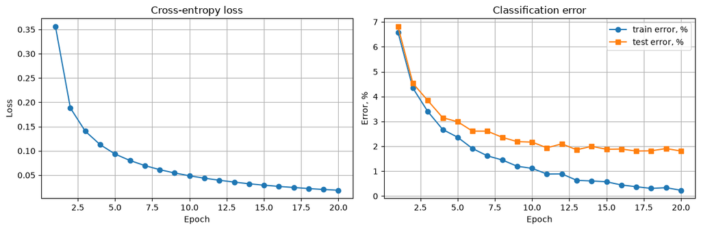

```python
test_acc  = accuracy(net, X_test,  y_test)
train_acc = accuracy(net, X_train, y_train)

print(f"Train Accuracy: {train_acc*100:.2f}%")
print(f"Train Error:    {(1 - train_acc) * 100:.2f}%")

print(f"Test  Accuracy: {test_acc*100:.2f}%")
print(f"Test  Error:    {(1 - test_acc)*100:.2f}%")

eps        = [h[0] for h in history]
losses     = [h[1] for h in history]
train_errs = [h[2] * 100 for h in history]
test_accs  = [h[3] * 100 for h in history]
test_errs  = [(1 - h[3]) * 100 for h in history]

fig, axes = plt.subplots(1, 2, figsize=(12, 4))
axes[0].plot(eps, losses, marker='o')
axes[0].set_title('Cross-entropy loss')
axes[0].set_xlabel('Epoch'); axes[0].set_ylabel('Loss'); axes[0].grid(True)

axes[1].plot(eps, train_errs, marker='o', label='train error, %')
axes[1].plot(eps, test_errs,  marker='s', label='test error, %')
axes[1].set_title('Classification error')
axes[1].set_xlabel('Epoch'); axes[1].set_ylabel('Error, %')
axes[1].legend(); axes[1].grid(True)
plt.tight_layout(); plt.show()
```

# Предсказания на тестовой выборке

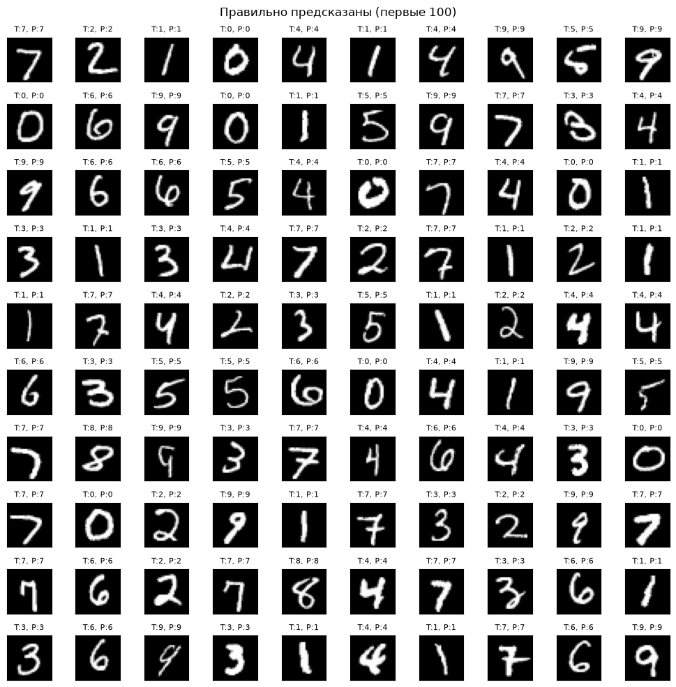

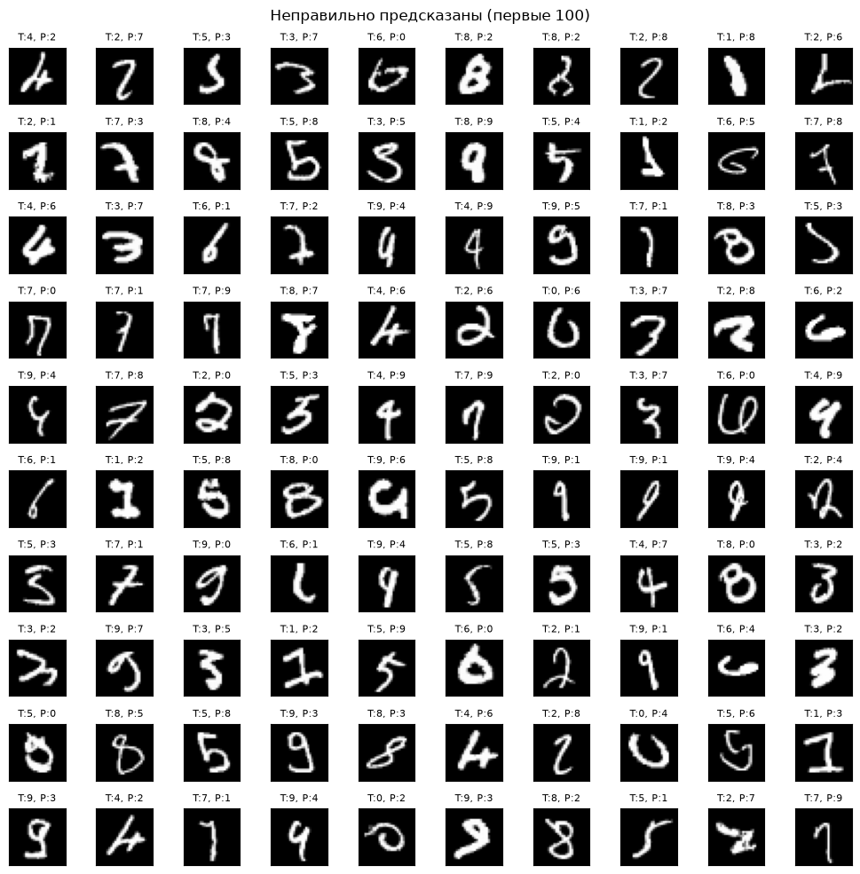

```python
y_pred = predict(net, X_test)

correct_mask   = (y_pred == y_test)
incorrect_mask = ~correct_mask

correct_idx   = np.where(correct_mask)[0]
incorrect_idx = np.where(incorrect_mask)[0]

show_images(
    test_images[correct_idx[:100]],
    [f"T:{y_test[i]}, P:{y_pred[i]}" for i in correct_idx[:100]],
    'Правильно предсказаны (первые 100)',
    num=100,
)

show_images(
    test_images[incorrect_idx[:100]],
    [f"T:{y_test[i]}, P:{y_pred[i]}" for i in incorrect_idx[:100]],
    'Неправильно предсказаны (первые 100)',
    num=100,
)
```